# Упражнение 8

Дунашов Константин

12 05 2021

# Задание:

Построить две модели для прогноза на основе дерева решений:

- для непрерывной зависимой переменной;
- для категориальной зависимой переменной.

Данные и переменные указаны в таблице с вариантами. Ядро генератора случайных чисел – номер варианта.

Для каждой модели:

- Указать настроечные параметры метода из своего варианта (например: количество узлов, количество предикторов, скорость обучения).
- Подогнать модель на обучающей выборке (50% наблюдений). Рассчитать MSE на тестовой выборке.
- Перестроить модель с помощью метода, указанного в варианте.
- Сделать прогноз по модели с подобранными в п.3 параметрами на тестовой выборке, оценить его точность и построить график «прогноз-реализация».

# Вариант 10

Модели: бэггинг (количество предикторов). Данные: ‘Auto {ISLR}’.

```r
# Название столбцов переменных
names(Auto)
```

```
## [1] "mpg"          "cylinders"    "displacement" "horsepower"   "weight"
## [6] "acceleration" "year"         "origin"       "name"
```

```r
# Размерность данных
dim(Auto)
```

```
## [1] 392   9
```

```r
# Ядро генератора случайных чисел
my.seed <- 10
```

# Модель 1 (для непрерывной зависимой переменной mpg)

```r
# Избавляемся от Name
Auto <- Auto[, -9]

head(Auto)
```

```
##   mpg cylinders displacement horsepower weight acceleration year origin
## 1  18         8          307        130   3504         12.0   70      1
## 2  15         8          350        165   3693         11.5   70      1
## 3  18         8          318        150   3436         11.0   70      1
## 4  16         8          304        150   3433         12.0   70      1
## 5  17         8          302        140   3449         10.5   70      1
## 6  15         8          429        198   4341         10.0   70      1
```

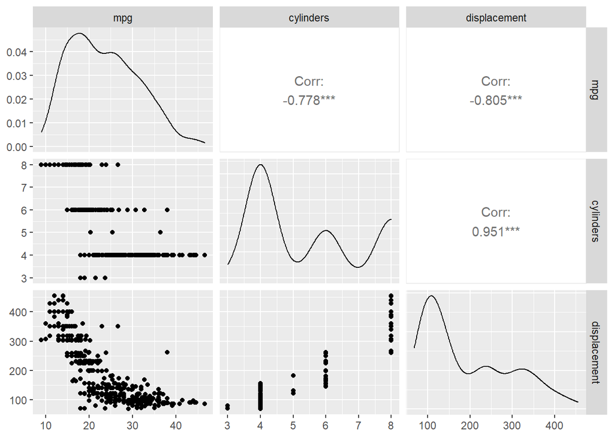

```r
# Матричные графики разброса переменных
# Матричные графики разброса переменных
p <- ggpairs(Auto[, c(1, 2:3)])
suppressMessages(print(p))
```

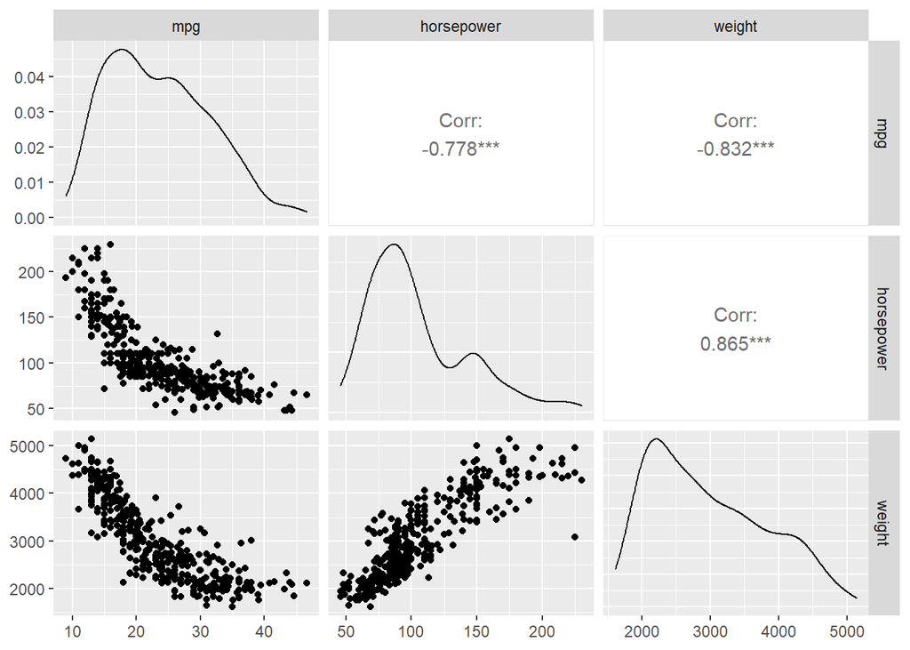

```r
p <- ggpairs(Auto[, c(1, 4:5)])
suppressMessages(print(p))
```

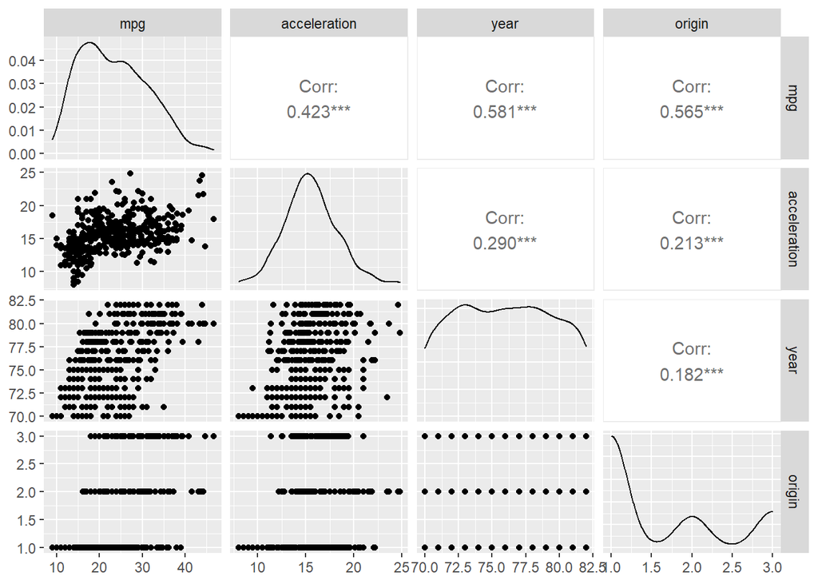

```r
p <- ggpairs(Auto[, c(1, 6:8)])
suppressMessages(print(p))
```

```r
# Обучающая выборка
set.seed(my.seed)
# Обучающая выборка - 50%
train <- sample(1:nrow(Auto), nrow(Auto)/2)
```

Построим дерево регрессии для зависимой переменной mpg

```r
# Обучаем модель
tree.auto <- tree(mpg ~ ., Auto, subset = train)
summary(tree.auto)
```

```
##
## Regression tree:
## tree(formula = mpg ~ ., data = Auto, subset = train)
## Variables actually used in tree construction:
## [1] "displacement" "year"         "weight"
## Number of terminal nodes:  9
## Residual mean deviance:  8.357 = 1563 / 187
## Distribution of residuals:
##    Min. 1st Qu.  Median    Mean 3rd Qu.    Max.
## -7.9050 -1.5020 -0.3897  0.0000  1.3200 14.2000
```

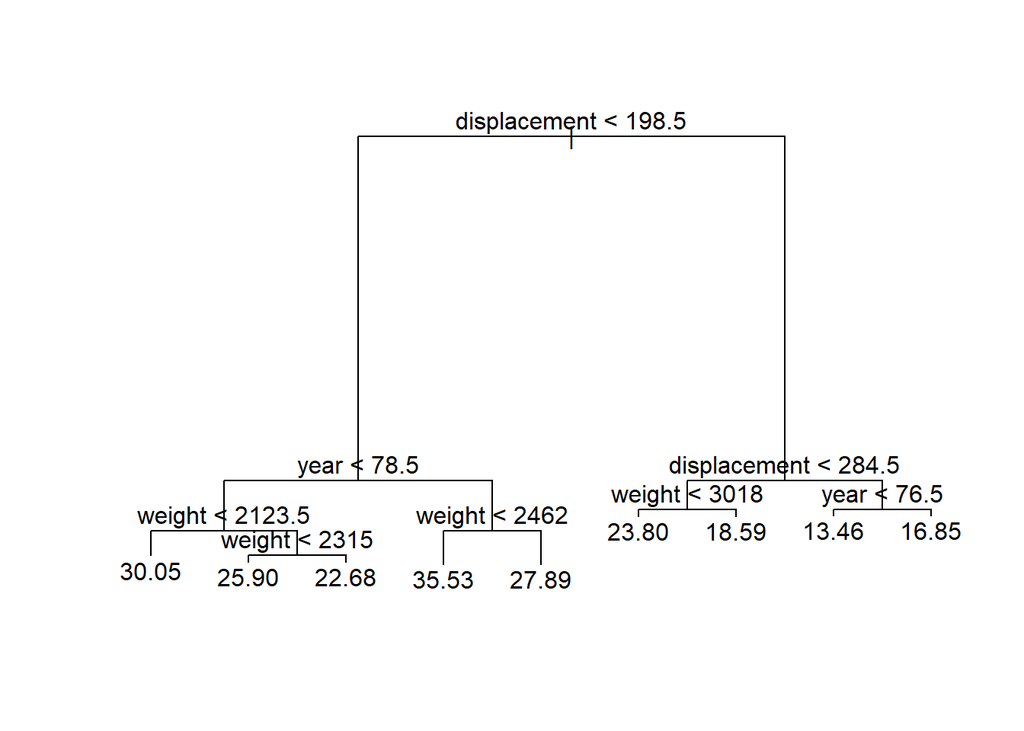

```r
# Визуализация
plot(tree.auto)
text(tree.auto, pretty = 0)
```

```r
tree.auto                    # Посмотреть всё дерево в консоли
```

```
## node), split, n, deviance, yval
##       * denotes terminal node
##
##  1) root 196 11130.00 22.83
##    2) displacement < 198.5 111  3263.00 27.90
##      4) year < 78.5 67  1041.00 25.51
##        8) weight < 2123.5 17   113.30 30.05 *
##        9) weight > 2123.5 50   459.30 23.97
##         18) weight < 2315 20   145.80 25.90 *
##         19) weight > 2315 30   188.70 22.68 *
##      5) year > 78.5 44  1257.00 31.54
##       10) weight < 2462 21   367.90 35.53 *
##       11) weight > 2462 23   247.80 27.89 *
##    3) displacement > 198.5 85  1301.00 16.22
##      6) displacement < 284.5 31   493.50 19.60
##       12) weight < 3018 6   256.40 23.80 *
##       13) weight > 3018 25   105.70 18.59 *
##      7) displacement > 284.5 54   250.20 14.28
##       14) year < 76.5 41   115.70 13.46 *
##       15) year > 76.5 13    21.53 16.85 *
```

```r
# Прогноз по модели
yhat <- predict(tree.auto, newdata = Auto[-train, ])
auto.test <- Auto[-train, "mpg"]

# MSE на тестовой выборке
mse.test <- mean((yhat - auto.test)^2)
names(mse.test)[length(mse.test)] <- 'Auto.regr.tree.all'
mse.test
```

```
## Auto.regr.tree.all
##           11.40431
```

```r
# Точность прогноза на тестовой выборке
acc.test <- sum(abs(yhat-auto.test))/sum(auto.test)
names(acc.test)[length(acc.test)] <- 'Auto.regr.tree.all'
acc.test
```

```
## Auto.regr.tree.all
##          0.1051395
```

# Бэггинг (модель 1)

Используем бэггинг, причем возбмем все 7 предикторов на каждом шаге.

```r
# бэггинг с 7 предикторами
set.seed(my.seed)
bag.auto <- randomForest(mpg ~ ., data = Auto, subset = train,
                           mtry = 7, importance = TRUE)

bag.auto
```

```
##
## Call:
##  randomForest(formula = mpg ~ ., data = Auto, mtry = 7, importance = TRUE,      subset = train)
##                Type of random forest: regression
##                      Number of trees: 500
## No. of variables tried at each split: 7
##
##           Mean of squared residuals: 9.389023
##                     % Var explained: 83.47
```

```r
# прогноз
yhat.bag = predict(bag.auto, newdata = Auto[-train, ])

# MSE на тестовой
mse.test <- c(mse.test, mean((yhat.bag - auto.test)^2))
names(mse.test)[length(mse.test)] <- 'Auto.bag.model.1.7'
mse.test
```

```
## Auto.regr.tree.all Auto.bag.model.1.7
##          11.404309           7.973838
```

```r
# Точность прогноза на тестовой выборке
acc.test <- sum(abs(yhat.bag-auto.test))/sum(auto.test)
names(acc.test)[length(acc.test)] <- 'Auto.regr.tree.model.1.7'
acc.test
```

```
## Auto.regr.tree.model.1.7
##               0.08442945
```

Ошибка на тестовой выборке равна 7.974. Можно изменить число деревьев с помощью аргумента.

```r
# Бэггинг с 7 предикторами и 25 деревьями
bag.auto <- randomForest(mpg ~ ., data = Auto, subset = train,
                           mtry = 7, ntree = 25)

# прогноз
yhat.bag <- predict(bag.auto, newdata = Auto[-train, ])

# MSE на тестовой
mse.test <- c(mse.test, mean((yhat.bag - auto.test)^2))
names(mse.test)[length(mse.test)] <- 'Auto.bag.model.1.7.25'
mse.test
```

```
##    Auto.regr.tree.all    Auto.bag.model.1.7 Auto.bag.model.1.7.25
##             11.404309              7.973838              8.404608
```

```r
# Точность прогноза на тестовой выборке
acc.test <- c(acc.test, sum(abs(yhat.bag-auto.test))/sum(auto.test))
names(acc.test)[length(acc.test)] <- 'Auto.regr.tree.model.1.7.25'
acc.test
```

```
##    Auto.regr.tree.model.1.7 Auto.regr.tree.model.1.7.25
##                  0.08442945                  0.08618288
```

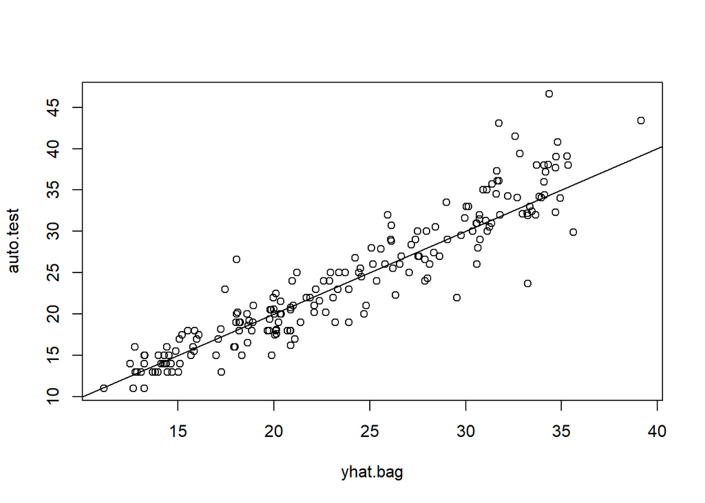

```r
# График прогноз - реализация
plot(yhat.bag, auto.test)
# линия идеального прогноза
abline(0, 1)
```

Судя по полученным результатам наименьшая MSE наблюдается у модели с использованием бэггинга с 7 предикторами. Минимальная MSE на тестовой выборке равна 7.97, точность прогноза составила 0.08.

# Модель 2 (для категориальной зависимой переменной high.mpg)

Загрузим таблицу с данными по расходу бензина, лошадиной силе и другая информации для автомобилей и добавим к ней переменную high.mpg - миль на галлон:

1, если миля на галлон >= 29; 0 - в противном случае.

```r
# Новая переменная
high.mpg <- ifelse(Auto$mpg < 29, '0', '1')
high.mpg <- factor(high.mpg, labels = c('yes', 'no'))

Auto$high.mpg <- high.mpg

# Название столбцов переменных
names(Auto)
```

```
## [1] "mpg"          "cylinders"    "displacement" "horsepower"   "weight"
## [6] "acceleration" "year"         "origin"       "high.mpg"
```

```r
# Размерность данных
dim(Auto)
```

```
## [1] 392   9
```

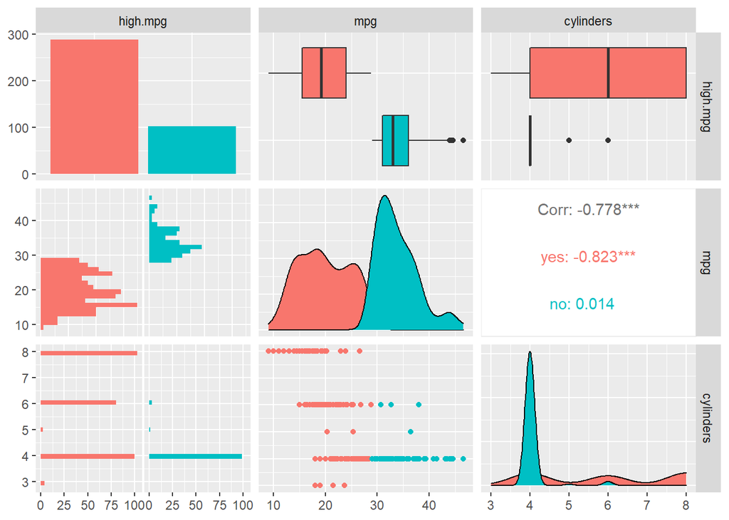

```r
# Матричные графики разброса переменных
p <- ggpairs(Auto[, c(9, 1:2)], aes(color = high.mpg))
suppressMessages(print(p))
```

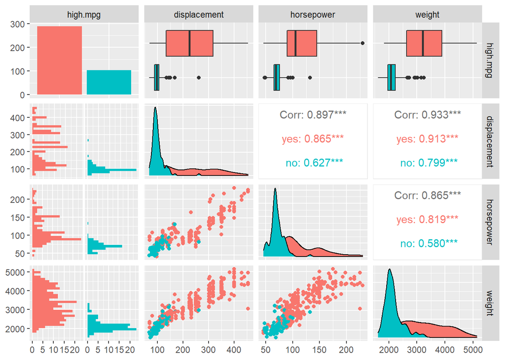

```r
p <- ggpairs(Auto[, c(9, 3:5)], aes(color = high.mpg))
suppressMessages(print(p))
```

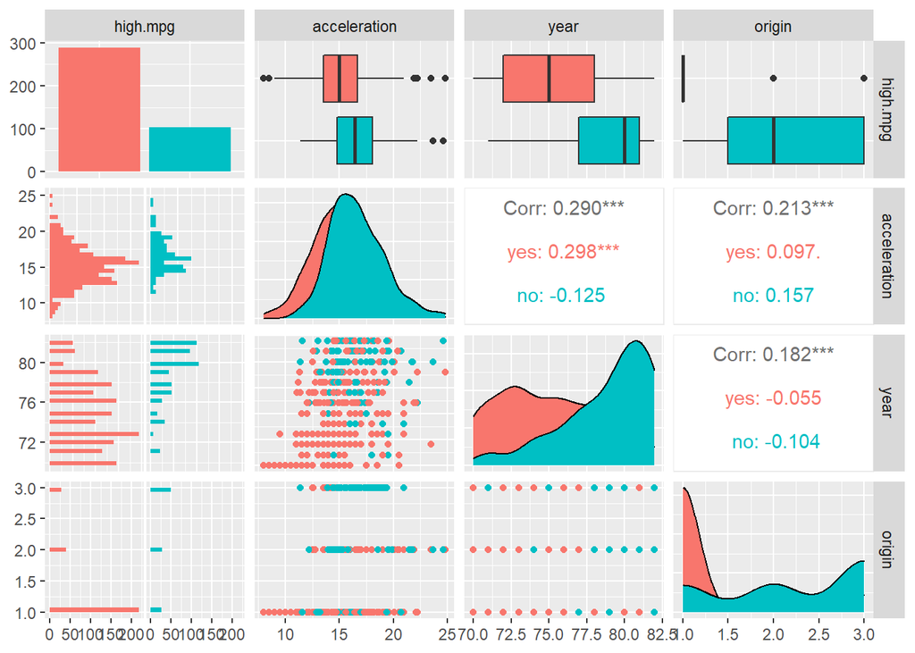

```r
p <- ggpairs(Auto[, c(9, 6:8)], aes(color = high.mpg))
suppressMessages(print(p))
```

Судя по графикам, класс 0 превосходит по размеру класс 1 по переменной high.mpg приблизительно в 3 раза. Классы на графиках разброса объясняющих переменных сильно смешаны, поэтому модели с непрерывной разрешающей границей вряд ли работают хорошо. Построим дерево для категориального отклика high.mpg, отбросив непрерывный отклик mpg (мы оставили его на первом графике, чтобы проверить, как сработало разделение по значению mpg = 29).

```r
# Модель бинарного  дерева
tree.auto <- tree(high.mpg ~ . -mpg, Auto)
summary(tree.auto)
```

```
##
## Classification tree:
## tree(formula = high.mpg ~ . - mpg, data = Auto)
## Variables actually used in tree construction:
## [1] "horsepower"   "year"         "weight"       "displacement"
## Number of terminal nodes:  10
## Residual mean deviance:  0.2449 = 93.56 / 382
## Misclassification error rate: 0.05102 = 20 / 392
```

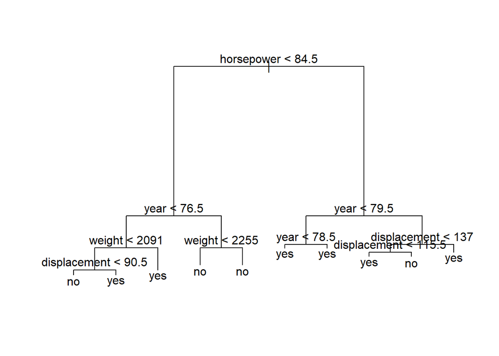

```r
# График результата
plot(tree.auto)                # Ветви
text(tree.auto, pretty = 0)    # Подписи
```

```r
tree.auto                      # Посмотреть всё дерево в консоли
```

```
## node), split, n, deviance, yval, (yprob)
##       * denotes terminal node
##
##  1) root 392 451.500 yes ( 0.737245 0.262755 )
##    2) horsepower < 84.5 132 161.900 no ( 0.303030 0.696970 )
##      4) year < 76.5 51  67.350 yes ( 0.627451 0.372549 )
##        8) weight < 2091 22  23.580 no ( 0.227273 0.772727 )
##         16) displacement < 90.5 15   7.348 no ( 0.066667 0.933333 ) *
##         17) displacement > 90.5 7   9.561 yes ( 0.571429 0.428571 ) *
##        9) weight > 2091 29  14.560 yes ( 0.931034 0.068966 ) *
##      5) year > 76.5 81  52.220 no ( 0.098765 0.901235 )
##       10) weight < 2255 58   0.000 no ( 0.000000 1.000000 ) *
##       11) weight > 2255 23  29.720 no ( 0.347826 0.652174 ) *
##    3) horsepower > 84.5 260  91.110 yes ( 0.957692 0.042308 )
##      6) year < 79.5 227  12.850 yes ( 0.995595 0.004405 )
##       12) year < 78.5 208   0.000 yes ( 1.000000 0.000000 ) *
##       13) year > 78.5 19   7.835 yes ( 0.947368 0.052632 ) *
##      7) year > 79.5 33  40.490 yes ( 0.696970 0.303030 )
##       14) displacement < 137 10  12.220 no ( 0.300000 0.700000 )
##         28) displacement < 115.5 5   6.730 yes ( 0.600000 0.400000 ) *
##         29) displacement > 115.5 5   0.000 no ( 0.000000 1.000000 ) *
##       15) displacement > 137 23  17.810 yes ( 0.869565 0.130435 ) *
```

Теперь построим дерево на обучающей выборке и оценим ошибку на тестовой.

```r
# Тестовая выборка
Auto.test <- Auto[-train,]
high.mpg.test <- high.mpg[-train]

# Строим дерево на обучающей выборке
tree.auto <- tree(high.mpg ~ . -mpg, Auto, subset = train)

# Делаем прогноз
tree.pred <- predict(tree.auto, Auto.test, type = "class")

# Матрица неточностей
tbl <- table(tree.pred, high.mpg.test)
tbl
```

```
##          high.mpg.test
## tree.pred yes  no
##       yes 131   8
##       no    5  52
```

```r
# ACC на тестовой
acc.test.2 <- sum(diag(tbl))/sum(tbl)
names(acc.test.2)[length(acc.test.2)] <- 'Auto.class.tree.all.model.2'
acc.test.2
```

```
## Auto.class.tree.all.model.2
##                   0.9336735
```

# Бэггинг (модель 2)

```r
set.seed(my.seed)
bag.auto <- randomForest(high.mpg ~ . -mpg, data = Auto, subset = train,
                           mtry = 7, importance = TRUE)
# График и таблица относительной важности переменных
summary(bag.auto)
```

```
##                 Length Class  Mode
## call               6   -none- call
## type               1   -none- character
## predicted        196   factor numeric
## err.rate        1500   -none- numeric
## confusion          6   -none- numeric
## votes            392   matrix numeric
## oob.times        196   -none- numeric
## classes            2   -none- character
## importance        28   -none- numeric
## importanceSD      21   -none- numeric
## localImportance    0   -none- NULL
## proximity          0   -none- NULL
## ntree              1   -none- numeric
## mtry               1   -none- numeric
## forest            14   -none- list
## y                196   factor numeric
## test               0   -none- NULL
## inbag              0   -none- NULL
## terms              3   terms  call
```

```r
# прогноз
yhat.bag <-  predict(bag.auto, newdata = Auto[-train, ])

# Матрица неточностей
tbl <- table(yhat.bag, high.mpg.test)
tbl
```

```
##         high.mpg.test
## yhat.bag yes  no
##      yes 133   9
##      no    3  51
```

```r
# Точность прогноза на тестовой выборке
acc.test.2 <- c(acc.test.2, sum(diag(tbl))/sum(tbl))
names(acc.test.2)[length(acc.test.2)] <- 'Auto.class.tree.model.2.7'
acc.test.2
```

```
## Auto.class.tree.all.model.2   Auto.class.tree.model.2.7
##                   0.9336735                   0.9387755
```

```r
# бэггинг с 7 предикторами и 25 деревьями
bag.auto <- randomForest(high.mpg ~ .-mpg, data = Auto, subset = train,
                           mtry = 7, ntree = 25)

# прогноз
yhat.bag <- predict(bag.auto, newdata = Auto[-train, ])

# Матрица неточностей
tbl <- table(yhat.bag, high.mpg.test)
tbl
```

```
##         high.mpg.test
## yhat.bag yes  no
##      yes 133   8
##      no    3  52
```

```r
# Точность прогноза на тестовой выборке
acc.test.2 <- c(acc.test.2, sum(diag(tbl))/sum(tbl))
names(acc.test.2)[length(acc.test.2)] <- 'Auto.class.tree.model.2.7.25'
acc.test.2
```

```
##  Auto.class.tree.all.model.2    Auto.class.tree.model.2.7
##                    0.9336735                    0.9387755
## Auto.class.tree.model.2.7.25
##                    0.9438776
```

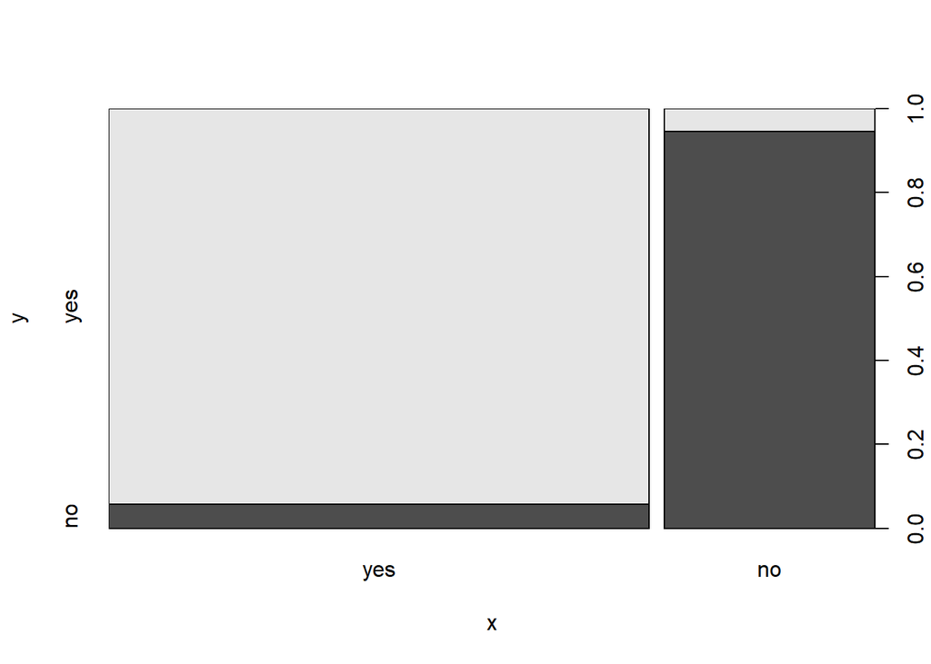

```r
# График "прогноз - реализация"
plot(yhat.bag, Auto$high.mpg[-train])
```